# Impact of dysfunctional ubiquitination in response to cancer immunotherapy

Somatic mutations analysis - Ubiquitin Gene Overrepresentation Analysis

Eric Bautista Farrerons (s212514)

First created on April 2024. Updated on 03 May 2024

# 1 Data pre-processing

### 1.0.1 Load data

```r
### Load required libraries
library(readxl)
library(tidyverse)
library(purrr)
library(dplyr)
library(knitr)
library(DT)
library(httr)
library(jsonlite)
library(stringr)
library(GSEABase)
library(HGNChelper)
library(mygene)
library(GO.db)
library(AnnotationDbi)
library(VennDiagram)

### Load functions
source(file = "../02_functions.R")

### Define paths
current_dir <- getwd()
data_path <- file.path(current_dir,
                       "../../data/_raw")
results_pc_path <- file.path(current_dir,
                              "../../results/patient_characteristics/output")
results_fip_path <- file.path(current_dir,
                              "../../results/somatic_mutation_analysis/functional_impact_prediction/output")
results_ubgenesets_path <- file.path(current_dir,
                                 "../../results/somatic_mutation_analysis/ubiquitin_custom_GS/output")
results_ubfora_path <- file.path(current_dir,
                                 "../../results/somatic_mutation_analysis/ubiquitin_fora/output")

# Create the folder if it does not exist
if(!file.exists(results_ubfora_path)) {
  dir.create(results_ubfora_path, recursive = TRUE)
}

figures_ubfora_path <- file.path(current_dir,
                                 "../../results/somatic_mutation_analysis/ubiquitin_fora/figures")

# Create the folder if it does not exist
if(!file.exists(figures_ubfora_path)) {
  dir.create(figures_ubfora_path, recursive = TRUE)
}

maf_df_path <- file.path(results_fip_path, "all_mutations.csv") # All mutations df
nonsyn_df_path <- file.path(results_fip_path, "nonsyn_mutations.csv") # Nonsyn mutations df
lof_df_path <- file.path(results_fip_path, "lof_mutations_reduced.csv") # LoF mutations df

# Sup1 data
sup1_response_path <- file.path(results_pc_path,
                           "sup1_response.csv")
### Read data & wrangle

# Read 3 lists of mutations

# All
maf_df_annotated <- read.csv(maf_df_path, header = TRUE)[ , -1]
list_of_all_mutations <- split(maf_df_annotated, maf_df_annotated$sample_id
                               )
# Nonsyn
nonsyn_df_annotated <- read.csv(nonsyn_df_path, header = TRUE)[ , -1]
list_of_nonsyn_mutations <- split(nonsyn_df_annotated, nonsyn_df_annotated$sample_id)

# LoF
lof_df_annotated <- read.csv(lof_df_path, header = TRUE)[ , -1]
list_of_lof_mutations <- split(lof_df_annotated, lof_df_annotated$sample_id)

# Get the list of patient IDs
sample_id_list <- unique(maf_df_annotated$sample_id)

## Read sup1_response.csv
sup1_response_df <- read.csv(sup1_response_path)[ , -1] # Drop first column

# df to merge response info later
response_df <- sup1_response_df %>%
  dplyr::rename(sample_id = Sample.ID,
                patient_response = Patient.Response) %>%
  dplyr::select(sample_id, patient_response)

# Create a list of Responders and Non-responders
sample_id_lists <- split(sup1_response_df$Sample.ID,
                         sup1_response_df$Patient.Response) # Split the "Sample.ID" values into lists based on "Patient.Response"

r_sample_ids <- sample_id_lists$R
nr_sample_ids <- sample_id_lists$NR
```

### 1.0.2 Correcting Hugo Symbols in input data

```r
# Load the GMT file
gene_sets_collection <- getGmt(file.path(data_path, "ubgenes.gmt"))

# Initialize an empty data frame for gene IDs
corrected_hsymbols <- data.frame(
  category = character(),
  description = character(),
  hugo_symbol = character(),
  corrected_hugo_symbol = character(),
  ensembl_id = character(),
  stringsAsFactors = FALSE
  )

# Extract gene sets and their descriptions
for (gene_set_id in names(gene_sets_collection)) {
  gene_set <- gene_sets_collection[[gene_set_id]]
  gene_ids <- geneIds(gene_set)
  description <- gene_set@shortDescription

  # Replace "/" with "-" in gene IDs
  gene_ids <- gsub("/", "-", gene_ids)

  # Reverse date-like hugo symbols
  gene_ids <- correct_date_like_symbols(gene_ids)

  # Create a temporary data frame for this gene set
  temp_df <- checkGeneSymbols(gene_ids)

  # Add missing columns to temp_df
  temp_df <- temp_df %>%
    dplyr::mutate(category = rep(gene_set_id, length(gene_ids)),
                  description = rep(description, length(gene_ids)))

  # Combine with the main data frame
  corrected_hsymbols <- rbind(corrected_hsymbols, temp_df)
}

# Split the gene_id where "///" is found and keep only the second part (if exists)
corrected_hsymbols$Suggested.Symbol <- sapply(str_split(corrected_hsymbols$Suggested.Symbol, " /// "), function(x) {
  if (length(x) > 1) {
    # If there's more than one part, keep the second one
    return(trimws(x[2]))
  } else {
    # If there's only one part, keep it as is
    return(trimws(x[1]))
  }
})

corrected_hsymbols <- corrected_hsymbols %>%
  dplyr::rename(c(hugo_symbol = x,
                  corrected_hugo_symbol = Suggested.Symbol)) %>%
  dplyr::select(category, description, hugo_symbol, corrected_hugo_symbol)
```

### 1.0.3 Filtering lists to only include Ubiquitin-related genes

```r
# Map HUGO symbols to Ensembl Gene IDs
corrected_hsymbols$ensembl_id <- SYMBOLtoENSEMBL(corrected_hsymbols$corrected_hugo_symbol)

# Check missing Ensembl IDs
missing_ensembl <- corrected_hsymbols %>%
  dplyr::filter(!str_detect(ensembl_id, "^ENSG"))

# Find them manually and update df (for now only Ensembl Gene IDs)
missing_ensembl <- missing_ensembl %>%
  dplyr::mutate(
    # corrected_hugo_symbol = case_when(
  #   hugo_symbol == "UBE2L5" ~ "UBE2L5P",
  #   hugo_symbol == "BABAM2" ~ "BRE",
  #   hugo_symbol == "COP1" ~ "RFWD2",
  #   hugo_symbol == "DCAF1" ~ "VPRBP",
  #   hugo_symbol == "DMAC2" ~ "ATP5SL",
  #   hugo_symbol == "ELOB" ~ "TCEB2",
  #   hugo_symbol == "FBH1" ~ "FBXO18",
  #   hugo_symbol == "FBXL21P" ~ "FBXL21",
  #   hugo_symbol == "MARCHF6" ~ "MARCH6",
  #   hugo_symbol == "1-Mar" ~ "MARCH1",
  #   hugo_symbol == "10-Mar" ~ "MARCH10",
  #   hugo_symbol == "11-Mar" ~ "MARCH11",
  #   hugo_symbol == "2-Mar" ~ "MARCH2",
  #   hugo_symbol == "3-Mar" ~ "MARCH3",
  #   hugo_symbol == "4-Mar" ~ "MARCH4",
  #   hugo_symbol == "5-Mar" ~ "MARCH5",
  #   hugo_symbol == "6-Mar" ~ "MARCH6",
  #   hugo_symbol == "7-Mar" ~ "MARCH7",
  #   hugo_symbol == "8-Mar" ~ "MARCH8",
  #   hugo_symbol == "9-Mar" ~ "MARCH9",
  #   hugo_symbol == "PARK2" ~ "PARK2",
  #   hugo_symbol == "RFWD2" ~ "RFWD2",
  #   hugo_symbol == "RNF212B" ~ "C14orf164",
  #   hugo_symbol == "RNF219" ~ "RNF219",
  #   hugo_symbol == "RNF225" ~ "RNF225",
  #   hugo_symbol == "TRIM75P" ~ "TRIM75P",
  #   hugo_symbol == "ZNF645" ~ "ZNF645",
  #   hugo_symbol == "USP17L1" ~ "USP17L1P",
  #   hugo_symbol == "OTULIN" ~ "FAM105B",
  #   TRUE ~ corrected_hugo_symbol
  # ),
  ensembl_id = case_when(
    hugo_symbol == "UBE2L5" ~ "ENSG00000236444",
    hugo_symbol == "BABAM2" ~ "ENSG00000158019",
    hugo_symbol == "COP1" ~ "ENSG00000143207",
    hugo_symbol == "DCAF1" ~ "ENSG00000145041",
    hugo_symbol == "DMAC2" ~ "ENSG00000105341",
    hugo_symbol == "ELOB" ~ "ENSG00000103363",
    hugo_symbol == "FBH1" ~ "ENSG00000134452",
    hugo_symbol == "FBXL21P" ~ "ENSG00000164616",
    hugo_symbol == "MARCHF6" ~ "ENSG00000145495",
    hugo_symbol == "1-Mar" ~ "ENSG00000145416",
    hugo_symbol == "10-Mar" ~ "ENSG00000173838",
    hugo_symbol == "11-Mar" ~ "ENSG00000183654",
    hugo_symbol == "2-Mar" ~ "ENSG00000099785",
    hugo_symbol == "3-Mar" ~ "ENSG00000173926",
    hugo_symbol == "4-Mar" ~ "ENSG00000144583",
    hugo_symbol == "5-Mar" ~ "ENSG00000198060",
    hugo_symbol == "6-Mar" ~ "ENSG00000145495",
    hugo_symbol == "7-Mar" ~ "ENSG00000136536",
    hugo_symbol == "8-Mar" ~ "ENSG00000165406",
    hugo_symbol == "9-Mar" ~ "ENSG00000139266",
    hugo_symbol == "PARK2" ~ "ENSG00000185345",
    hugo_symbol == "RFWD2" ~ "ENSG00000143207",
    hugo_symbol == "RNF212B" ~ "ENSG00000215277",
    hugo_symbol == "RNF219" ~ "ENSG00000152193",
    hugo_symbol == "RNF225" ~ "ENSG00000269855",
    hugo_symbol == "TRIM75P" ~ "ENSG00000250374",
    hugo_symbol == "ZNF645" ~ "ENSG00000175809",
    hugo_symbol == "USP17L1" ~ "ENSG00000230549",
    hugo_symbol == "OTULIN" ~ "ENSG00000154124",
    TRUE ~ ensembl_id
  ))

# Merge the dataframes
corrected_hsymbols_updated <- corrected_hsymbols %>%
  left_join(dplyr::select(missing_ensembl,
                          hugo_symbol,
                          # new_corrected_hugo_symbol = corrected_hugo_symbol,
                          new_ensembl_id = ensembl_id),
            by = "hugo_symbol")

# Update the values based on the join
corrected_hsymbols_updated <- corrected_hsymbols_updated %>%
  dplyr::mutate(
    # corrected_hugo_symbol = ifelse(!is.na(new_corrected_hugo_symbol), new_corrected_hugo_symbol, corrected_hugo_symbol),
    ensembl_id = ifelse(!is.na(new_ensembl_id), new_ensembl_id, ensembl_id)
    ) %>%
  dplyr::select(
    # -new_corrected_hugo_symbol,
    -new_ensembl_id, -hugo_symbol)

# Extract the ensembl_id column to do the filtering
ubiquitin_df <- corrected_hsymbols_updated %>%
  dplyr::select(ensembl_id)

# Get ubiquitin unique ensembl ids
ub_ensembl_ids <- unique(corrected_hsymbols_updated$ensembl_id)

# Filter for ubiquitin genes in all the mutation lists
list_of_all_ub_mutations <- ubiquitin_filter(list_of_all_mutations, ubiquitin_df)
list_of_nonsyn_ub_mutations <- ubiquitin_filter(list_of_nonsyn_mutations, ubiquitin_df)
list_of_lof_ub_mutations <- ubiquitin_filter(list_of_lof_mutations, ubiquitin_df)

# Bind rows to re-generate the dataframes
all_df_ubiquitin <- bind_rows(list_of_all_ub_mutations)
nonsyn_df_ubiquitin <- bind_rows(list_of_nonsyn_ub_mutations)
lof_df_ubiquitin <- bind_rows(list_of_lof_ub_mutations)

# Eliminate duplicates?

# Get all unique sample_id values
unique_sample_ids <- unique(list_of_lof_ub_mutations$sample_id)
```

# 2 Summary of mutations per patient

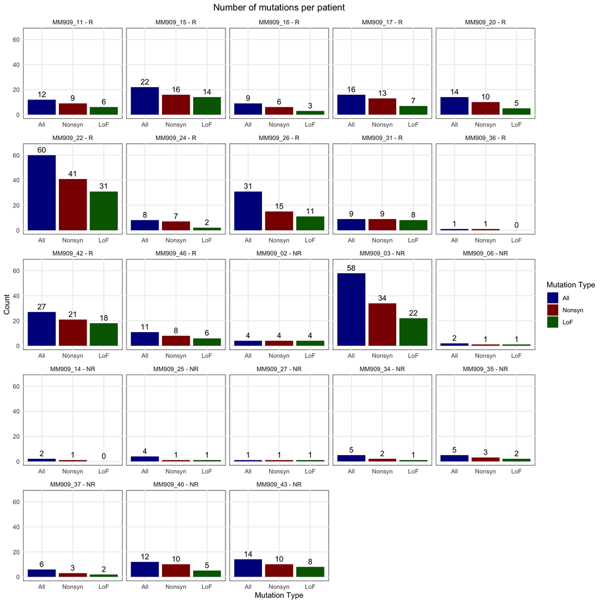

```r
# Define output path
mm909_sum_plot_path <- file.path(figures_ubfora_path,
                              "mm909_sum_plot.png")

# Summary plot
mm909_sum_plot <- sum_plot(response_df, all_df_ubiquitin, nonsyn_df_ubiquitin, lof_df_ubiquitin, mm909_sum_plot_path)

# Display
print(mm909_sum_plot)
```

Sample MM909_47 does not have any Ubiquitin-related gene. There are 158 ubiquitin LoF mutations in total.

# 3 Define Gene Sets based on input file

```r
# Count how many genes each category has initially
raw_category_gene_count <- corrected_hsymbols_updated %>%
  dplyr::group_by(category, description) %>%
  dplyr::summarise(row_count = n()) %>%
  dplyr::arrange(desc(row_count)) %>%
  dplyr::ungroup() %>%
  dplyr::rename(gene_count = row_count)

# Add total count row
total_count <- sum(raw_category_gene_count$gene_count)
summary_row <- tibble(category = "Total", description = "All Categories", gene_count = total_count)
raw_category_gene_count <- bind_rows(raw_category_gene_count, summary_row)

# Display table
datatable(raw_category_gene_count,
          extensions = c('Buttons',
                         'FixedColumns'),
          options = list(
            dom = 'Bfrtip',
            buttons = c('copy', 'excel', 'csv'),
            scrollX=TRUE,
            pageLength=10,
            fixedColumns = list(leftColumns = 1), # Freeze the first column
            columnDefs = list(list(
              targets = "_all",
              render = JS(
                "function(data, type, row, meta) {",
                "  return data === null ? 'NA' : data;",
                "}"
              )
            ))
          ),
          caption = "Count of genes included in each ubiquitin category (directly from the file)."
        )
```

|  | category | description | gene_count |
| --- | --- | --- | --- |
| 1 | E3_genes | Ubiquitin-protein ligase family | 555 |
| 2 | C19_genes | Peptidase family C19 | 71 |
| 3 | dub_genes | Deubiquitinases | 53 |
| 4 | E2_genes | Ubiquitin-conjugating enzymes | 41 |
| 5 | E1_genes | Ubiquitin-activating enzymes | 9 |
| 6 | Total | All Categories | 729 |

There are 729 ubiquitin-related genes in the file. The category E3_genes (Ubiquitin-protein ligase family) is largely overrepresented compared to the others. And the category E1_genes (Ubiquitin-activating enzymes) is underrepresented.

A brief description of the ubiquitin protein families described here: The ubiquitinylation process is now known to be performed by several enzymes in sequence, starting with EC 6.2.1.45 (ubiquitin-activating enzyme E1) and followed by several transfer reactions, including those of EC 2.3.2.23 (E2 ubiquitin-conjugating enzyme) and EC 2.3.2.27 (RING-type E3 ubiquitin transferase) [Ref](https://www.brenda-enzymes.org/enzyme.php?ecno=6.3.2.19).

Ubiquitin carboxyl-terminal hydrolases (UCH) or Deubiquitinases (DUBs) (EC 3.4.19.12) are thiol proteases that recognise and hydrolyse the peptide bond at the C-terminal glycine of ubiquitin. These enzymes are involved in the processing of poly-ubiquitin precursors as well as that of ubiquinated proteins. The deubiquitinsing proteases can be split into 2 size ranges, 20-30kDa (IPR001578) and 100-200kDa: the second class consist of large proteins (800 to 2000 residues) that belong to the peptidase family C19, and this group is currently represented by yeast UBP1 [Ref](https://www.ebi.ac.uk/interpro/entry/InterPro/IPR001394/).

**In summary, E1, E2 and E3 are enzymes involved in “protein ubiquitination”, whereas C19 and dub are enzymes involved in “protein deubiquitination”.**

# 4 Divide LoF mutations for responders and non-responders

```r
# Add category and description to genes
cat_lof_df_ubiquitin <- lof_df_ubiquitin %>%
  dplyr::left_join(corrected_hsymbols_updated, by="ensembl_id")

# Add response
annot_lof_df_ubiquitin <- cat_lof_df_ubiquitin %>%
  dplyr::left_join(response_df, by="sample_id") %>%
  dplyr::distinct()

# Responders
r_lof_ub_df <- annot_lof_df_ubiquitin %>%
  dplyr::filter(sample_id %in% r_sample_ids)

# Non-responders
nr_lof_ub_df <- annot_lof_df_ubiquitin %>%
  dplyr::filter(sample_id %in% nr_sample_ids)
```

There are 110 LoF mutations for ubiquitin-related genes in responders in total.

There are 47 LoF mutations for ubiquitin-related genes in non-responders in total.

```r
# Display tables
datatable(r_lof_ub_df,
          extensions = c('Buttons',
                         'FixedColumns'),
          options = list(
            dom = 'Bfrtip',
            buttons = c('copy', 'excel', 'csv'),
            scrollX=TRUE,
            pageLength=10,
            fixedColumns = list(leftColumns = 2), # Freeze the first 2 columns
            columnDefs = list(list(
              targets = "_all",
              render = JS(
                "function(data, type, row, meta) {",
                "  return data === null ? 'NA' : data;",
                "}"
              )
            ))
          ),
          caption = "LoF mutations for ub-related genes in Responders."
        )
```

|  | sample_id | ensembl_id | entrez_id | hugo_symbol | Location | Allele | Liberal_consequence | category | description | corrected_hugo_symbol | patient_response |
| --- | --- | --- | --- | --- | --- | --- | --- | --- | --- | --- | --- |
| 1 | MM909_11 | ENSG00000121236 | 117854 | TRIM6 | 11:5626615-5626615 | G | deleterious | E3_genes | Ubiquitin-protein ligase family | TRIM6 | R |
| 2 | MM909_11 | ENSG00000198795 | 25925 | ZNF521 | 18:22805061-22805061 | C | deleterious | E3_genes | Ubiquitin-protein ligase family | ZNF521 | R |
| 3 | MM909_11 | ENSG00000198795 | 25925 | ZNF521 | 18:22902104-22902104 | G | deleterious | E3_genes | Ubiquitin-protein ligase family | ZNF521 | R |
| 4 | MM909_11 | ENSG00000175556 | 79836 | LONRF3 | X:118151504-118151504 | T | deleterious | E3_genes | Ubiquitin-protein ligase family | LONRF3 | R |
| 5 | MM909_11 | ENSG00000114374 | 8287 | USP9Y | Y:14848410-14848410 | T | deleterious | C19_genes | Peptidase family C19 | USP9Y | R |
| 6 | MM909_11 | ENSG00000114374 | 8287 | USP9Y | Y:14848410-14848410 | T | deleterious | dub_genes | Deubiquitinases | USP9Y | R |
| 7 | MM909_15 | ENSG00000072609 | 55743 | CHFR | 12:133418177-133418177 | C | deleterious | E3_genes | Ubiquitin-protein ligase family | CHFR | R |
| 8 | MM909_15 | ENSG00000103657 | 8925 | HERC1 | 15:63954030-63954030 | A | deleterious | E3_genes | Ubiquitin-protein ligase family | HERC1 | R |
| 9 | MM909_15 | ENSG00000103194 | 9100 | USP10 | 16:84778721-84778722 | TT | deleterious | C19_genes | Peptidase family C19 | USP10 | R |
| 10 | MM909_15 | ENSG00000103194 | 9100 | USP10 | 16:84778721-84778722 | TT | deleterious | dub_genes | Deubiquitinases | USP10 | R |

[output cut: 100 more lines]

```r
datatable(nr_lof_ub_df,
          extensions = c('Buttons',
                         'FixedColumns'),
          options = list(
            dom = 'Bfrtip',
            buttons = c('copy', 'excel', 'csv'),
            scrollX=TRUE,
            pageLength=10,
            fixedColumns = list(leftColumns = 2), # Freeze the first 2 columns
            columnDefs = list(list(
              targets = "_all",
              render = JS(
                "function(data, type, row, meta) {",
                "  return data === null ? 'NA' : data;",
                "}"
              )
            ))
          ),
          caption = "LoF mutations for ub-related genes in Non-responders."
        )
```

|  | sample_id | ensembl_id | entrez_id | hugo_symbol | Location | Allele | Liberal_consequence | category | description | corrected_hugo_symbol | patient_response |
| --- | --- | --- | --- | --- | --- | --- | --- | --- | --- | --- | --- |
| 1 | MM909_02 | ENSG00000132972 | 56163 | RNF17 | 13:25367199-25367199 | A | deleterious | E3_genes | Ubiquitin-protein ligase family | RNF17 | NR |
| 2 | MM909_02 | ENSG00000005810 | 23077 | MYCBP2 | 13:77672278-77672278 | A | deleterious | E3_genes | Ubiquitin-protein ligase family | MYCBP2 | NR |
| 3 | MM909_02 | ENSG00000182670 | 286495 | TTC3 | 21:38525385-38525385 | T | deleterious | E3_genes | Ubiquitin-protein ligase family | TTC3 | NR |
| 4 | MM909_02 | ENSG00000155890 | 287015 | TRIM42 | 3:140419773-140419773 | A | deleterious | E3_genes | Ubiquitin-protein ligase family | TRIM42 | NR |
| 5 | MM909_03 | ENSG00000185345 | 5071 | PARK2 | 6:161771227-161771227 | T | deleterious | E3_genes | Ubiquitin-protein ligase family | PRKN | NR |
| 6 | MM909_03 | ENSG00000133606 | 23608 | MKRN1 | 7:140159669-140159669 | A | deleterious | E3_genes | Ubiquitin-protein ligase family | MKRN1 | NR |
| 7 | MM909_03 | ENSG00000105428 | 148066 | ZNRF4 | 19:5456158-5456158 | T | deleterious | E3_genes | Ubiquitin-protein ligase family | ZNRF4 | NR |
| 8 | MM909_03 | ENSG00000197323 | 51592 | TRIM33 | 1:114968303-114968303 | A | deleterious | E3_genes | Ubiquitin-protein ligase family | TRIM33 | NR |
| 9 | MM909_03 | ENSG00000182053 | 283116 | TRIM49B | 11:49053185-49053185 | A | deleterious | E3_genes | Ubiquitin-protein ligase family | TRIM49B | NR |
| 10 | MM909_03 | ENSG00000132972 | 56163 | RNF17 | 13:25416281-25416281 | C | deleterious | E3_genes | Ubiquitin-protein ligase family | RNF17 | NR |

[output cut: 37 more lines]

# 5 Tables of Gene Sets

## 5.1 Global

```r
# Count how many genes each category has (R & NR)
glob_category_gene_count <- annot_lof_df_ubiquitin %>%
  dplyr::group_by(category, description) %>%
  dplyr::summarise(row_count = n()) %>%
  dplyr::arrange(desc(row_count)) %>%
  dplyr::ungroup() %>%
  dplyr::rename(mutation_count = row_count)

# Get unique ensembl ids
glob_unique_ensembl_ids <- annot_lof_df_ubiquitin %>%
  dplyr::select(ensembl_id) %>%
  dplyr::distinct() %>%
  dplyr::pull(ensembl_id)

# Add total count row
total_count <- sum(glob_category_gene_count$mutation_count)
summary_row <- tibble(category = "Total", description = "All Categories", mutation_count = total_count)
glob_category_gene_count <- bind_rows(glob_category_gene_count, summary_row)

# Display table
datatable(glob_category_gene_count,
          extensions = c('Buttons',
                         'FixedColumns'),
          options = list(
            dom = 'Bfrtip',
            buttons = c('copy', 'excel', 'csv'),
            scrollX=TRUE,
            pageLength=10,
            fixedColumns = list(leftColumns = 1), # Freeze the first column
            columnDefs = list(list(
              targets = "_all",
              render = JS(
                "function(data, type, row, meta) {",
                "  return data === null ? 'NA' : data;",
                "}"
              )
            ))
          ),
          caption = "Count of mutations in genes included in each ubiquitin category for Responders and Non-responders."
        )
```

|  | category | description | mutation_count |
| --- | --- | --- | --- |
| 1 | E3_genes | Ubiquitin-protein ligase family | 110 |
| 2 | C19_genes | Peptidase family C19 | 22 |
| 3 | dub_genes | Deubiquitinases | 21 |
| 4 | E1_genes | Ubiquitin-activating enzymes | 3 |
| 5 | E2_genes | Ubiquitin-conjugating enzymes | 1 |
| 6 | Total | All Categories | 157 |

So, we have 157 mutations in 106 genes.

## 5.2 Responders

```r
# Count how many genes each category has (R)
r_category_gene_count <- r_lof_ub_df %>%
  dplyr::group_by(category, description) %>%
  dplyr::summarise(row_count = n()) %>%
  dplyr::arrange(desc(row_count)) %>%
  dplyr::ungroup() %>%
  dplyr::rename(mutation_count = row_count)

# Get unique ensembl ids
r_unique_ensembl_ids <- r_lof_ub_df %>%
  dplyr::select(ensembl_id) %>%
  dplyr::distinct() %>%
  dplyr::pull(ensembl_id)

# Add total count row
total_count <- sum(r_category_gene_count$mutation_count)
summary_row <- tibble(category = "Total", description = "All Categories", mutation_count = total_count)
r_category_gene_count <- bind_rows(r_category_gene_count, summary_row)

# Display table
datatable(r_category_gene_count,
          extensions = c('Buttons',
                         'FixedColumns'),
          options = list(
            dom = 'Bfrtip',
            buttons = c('copy', 'excel', 'csv'),
            scrollX=TRUE,
            pageLength=10,
            fixedColumns = list(leftColumns = 1), # Freeze the first column
            columnDefs = list(list(
              targets = "_all",
              render = JS(
                "function(data, type, row, meta) {",
                "  return data === null ? 'NA' : data;",
                "}"
              )
            ))
          ),
          caption = "Count of mutations in genes included in each ubiquitin category for Responders."
        )
```

|  | category | description | mutation_count |
| --- | --- | --- | --- |
| 1 | E3_genes | Ubiquitin-protein ligase family | 73 |
| 2 | C19_genes | Peptidase family C19 | 17 |
| 3 | dub_genes | Deubiquitinases | 17 |
| 4 | E1_genes | Ubiquitin-activating enzymes | 2 |
| 5 | E2_genes | Ubiquitin-conjugating enzymes | 1 |
| 6 | Total | All Categories | 110 |

So, we have 110 mutations in 78 genes.

## 5.3 Non-responders

```r
# Count how many genes each category has (NR)
nr_category_gene_count <- nr_lof_ub_df %>%
  dplyr::group_by(category, description) %>%
  dplyr::summarise(row_count = n()) %>%
  dplyr::arrange(desc(row_count)) %>%
  dplyr::ungroup() %>%
  dplyr::rename(mutation_count = row_count)

# Get unique ensembl ids
nr_unique_ensembl_ids <- nr_lof_ub_df %>%
  dplyr::select(ensembl_id) %>%
  dplyr::distinct() %>%
  dplyr::pull(ensembl_id)

# Add total count row
total_count <- sum(nr_category_gene_count$mutation_count)
summary_row <- tibble(category = "Total", description = "All Categories", mutation_count = total_count)
nr_category_gene_count <- bind_rows(nr_category_gene_count, summary_row)

# Display table
datatable(nr_category_gene_count,
          extensions = c('Buttons',
                         'FixedColumns'),
          options = list(
            dom = 'Bfrtip',
            buttons = c('copy', 'excel', 'csv'),
            scrollX=TRUE,
            pageLength=10,
            fixedColumns = list(leftColumns = 1), # Freeze the first column
            columnDefs = list(list(
              targets = "_all",
              render = JS(
                "function(data, type, row, meta) {",
                "  return data === null ? 'NA' : data;",
                "}"
              )
            ))
          ),
          caption = "Count of mutations in genes included in each ubiquitin category for Non-responders."
        )
```

|  | category | description | mutation_count |
| --- | --- | --- | --- |
| 1 | E3_genes | Ubiquitin-protein ligase family | 37 |
| 2 | C19_genes | Peptidase family C19 | 5 |
| 3 | dub_genes | Deubiquitinases | 4 |
| 4 | E1_genes | Ubiquitin-activating enzymes | 1 |
| 5 | Total | All Categories | 47 |

So, we have 47 mutations in 38 genes.

# 6 Find commonalities and differences between response groups

## 6.1 Functional OverRepresentation Analysis (FORA)

```r
# Perform FORA analysis
# Define paths
fora_results_all_csv_path <- file.path(results_ubfora_path, "fora_results_ubiquitin_all.csv")
fora_results_nonsyn_csv_path <- file.path(results_ubfora_path, "fora_results_ubiquitin_nonsyn.csv")
fora_results_lof_csv_path <- file.path(results_ubfora_path, "fora_results_ubiquitin_lof.csv")

# Adapt structure to gene_sets_list
gene_sets_df <- annot_lof_df_ubiquitin %>%
  dplyr::group_by(description) %>%
  dplyr::summarise(ensembl_ids = list(unique(ensembl_id)), .groups = 'drop')

# Convert the dataframe to a named list
gene_sets_list <- setNames(gene_sets_df$ensembl_ids, gene_sets_df$description)

# Perform FORA analysis for Ubiquitin Gene Sets
# perform_fora_analysis(sample_id_list, list_of_all_ub_mutations, list_of_nonsyn_ub_mutations, list_of_lof_ub_mutations, fora_results_all_csv_path, fora_results_nonsyn_csv_path, fora_results_lof_csv_path, gene_sets_list=gene_sets_list)

# Load fora results
fora_results_ubiquitin_all_df <- read.csv(fora_results_all_csv_path, header = TRUE)[ , -1]
fora_results_ubiquitin_nonsyn_df <- read.csv(fora_results_nonsyn_csv_path, header = TRUE)[ , -1]
fora_results_ubiquitin_lof_df <- read.csv(fora_results_lof_csv_path, header = TRUE)[ , -1]
```

## 6.2 Explore shared mutated genes

```r
# Get genes for each response group
responder_genes <- annot_lof_df_ubiquitin %>%
  dplyr::filter(patient_response == "R") %>%
  pull(corrected_hugo_symbol) %>%
  unique()

non_responder_genes <- annot_lof_df_ubiquitin %>%
  dplyr::filter(patient_response == "NR") %>%
  pull(corrected_hugo_symbol) %>%
  unique()

# Identify unique and shared genes
shared_genes <- intersect(responder_genes, non_responder_genes)
unique_responder_genes <- setdiff(responder_genes, shared_genes)
unique_non_responder_genes <- setdiff(non_responder_genes, shared_genes)

# Define the lists for the Venn diagram
gene_lists <- list(
  Responder = responder_genes,
  Non_responder = non_responder_genes
)

# Set up PNG device to save the plot
venn_path <- file.path(figures_ubfora_path, "venn_diagram_shared_genes.png")
png(filename = venn_path, width = 1200, height = 800, res = 300)

# Generate Venn diagram
venn.plot <- draw.pairwise.venn(
  area1 = length(responder_genes),
  area2 = length(non_responder_genes),
  cross.area = length(shared_genes),
  category = c("Responders", "Non-responders"),
  fill = c("#0073C2FF", "#CD534CFF"),
  cex = 1,        # Adjust font size of numbers
  cat.cex = 1,  # Adjust category label font size
  cat.col = c("black", "black"),
  cat.pos = 0,         # Positions for category names (0 degrees, on top)
  cat.dist = 0.07,     # Increase this if labels overlap with the circles
  euler.d = TRUE,      # Force circles to be more circular
  lwd = 2,      # Line width
  filename = NULL
)

# Display the plot
grid.newpage()
grid.draw(venn.plot)

# Add shared gene labels
x_coords <- c(0.05, 0.15, 0.25, 0.35, 0.45, 0.55, 0.65, 0.75, 0.87, 0.97)
y_coords <- c(0.05, 0.05, 0.05, 0.05, 0.05, 0.05, 0.05, 0.05, 0.05, 0.05)

# Define starting points for the arrows
x_start <- 0.6
y_start <- 0.4

# Loop through each gene to add labels and arrows
for (i in seq_along(shared_genes)) {
  # Add gene label
  grid.text(shared_genes[i],
            x = x_coords[i],
            y = y_coords[i],
            just = c("center", "bottom"),
            gp = gpar(col = "black", fontsize = 6, fontface = "bold"))

  # Draw a line with an arrow pointing to each gene label
  grid.lines(x = c(x_start, x_coords[i]), y = c(y_start, y_coords[i]+0.04),
             arrow = arrow(type = "open", length = unit(1, "mm")),
             gp = gpar(col = "black", lwd = 1))
}

# Save the plot
dev.off()
```

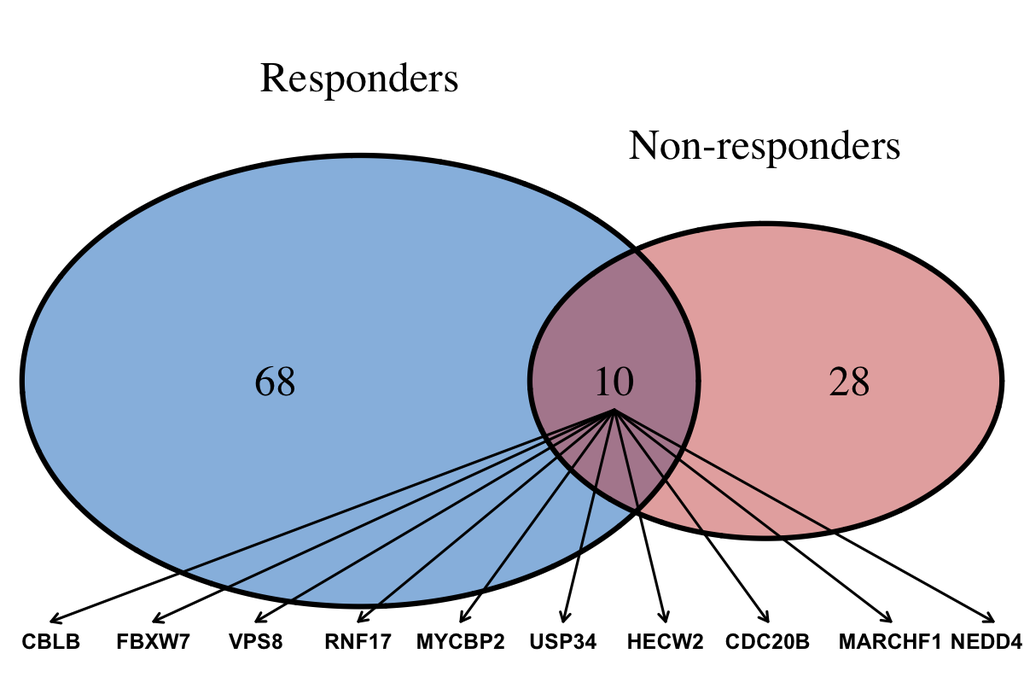

```r
knitr::include_graphics(venn_path)
```

So they share 10 genes. Below is a table of these genes:

```r
# Filter by shared genes
shared_genes_df <- annot_lof_df_ubiquitin %>%
  dplyr::filter(corrected_hugo_symbol %in% shared_genes) %>%
  dplyr::select(corrected_hugo_symbol, category, description) %>%
  dplyr::distinct()

# Display table
datatable(shared_genes_df,
          extensions = c('Buttons',
                         'FixedColumns'),
          options = list(
            dom = 'Bfrtip',
            buttons = c('copy', 'excel', 'csv'),
            scrollX=TRUE,
            pageLength=11,
            fixedColumns = list(leftColumns = 1), # Freeze the first column
            columnDefs = list(list(
              targets = "_all",
              render = JS(
                "function(data, type, row, meta) {",
                "  return data === null ? 'NA' : data;",
                "}"
              )
            ))
          ),
          caption = "Shared genes between Responders and Non-responders."
        )
```

|  | corrected_hugo_symbol | category | description |
| --- | --- | --- | --- |
| 1 | RNF17 | E3_genes | Ubiquitin-protein ligase family |
| 2 | MYCBP2 | E3_genes | Ubiquitin-protein ligase family |
| 3 | NEDD4L | E3_genes | Ubiquitin-protein ligase family |
| 4 | HECW2 | E3_genes | Ubiquitin-protein ligase family |
| 5 | MARCHF1 | E3_genes | Ubiquitin-protein ligase family |
| 6 | CBLB | E3_genes | Ubiquitin-protein ligase family |
| 7 | FBXW7 | E3_genes | Ubiquitin-protein ligase family |
| 8 | VPS8 | E3_genes | Ubiquitin-protein ligase family |
| 9 | USP34 | C19_genes | Peptidase family C19 |
| 10 | USP34 | dub_genes | Deubiquitinases |

[output cut: 1 more lines]

## 6.3 LoF mutations in all Ubiquitin genes in R and NR (both shared and unique)

### 6.3.1 Bubble plot

This does not have the filter p.adjust < 0.05.

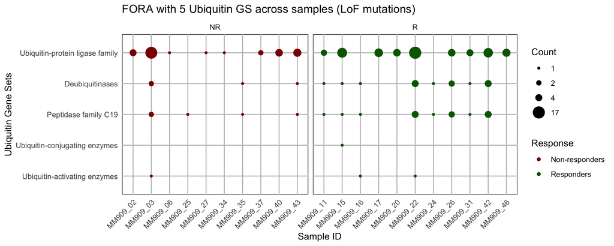

```r
# Define output path
mm909_ubiquitin_lof_plot_path <- file.path(figures_ubfora_path,
                              "ub_all_bubble_plot_RvsNR.png")

mm909_ubiquitin_lof_plot <- bubble_plot_all(response_df, fora_results_ubiquitin_lof_df, mm909_ubiquitin_lof_plot_path, "FORA with 5 Ubiquitin GS across samples (LoF mutations)", "Ubiquitin Gene Sets")

print(mm909_ubiquitin_lof_plot)
```

### 6.3.2 Heat map

This does not have the filter p.adjust < 0.05.

```r
plot_path <- file.path(figures_ubfora_path, "ub_all_heat_map_RvsNR.pdf")
combinedGS_lof_plot <- complex_heatmap_genesets(response_df, fora_results_ubiquitin_lof_df, plot_path,
                                    "Heat Map gene counts per Gene Set stratified by patient", 16, 6)

# Print
print(combinedGS_lof_plot)
```

[output not shown]

## 6.4 LoF mutations in unique Ubiquitin genes in R and NR

```r
# Filter genes
r_annot_lof_df_ubiquitin <- annot_lof_df_ubiquitin %>%
  dplyr::filter(corrected_hugo_symbol %in% unique_responder_genes)
nr_annot_lof_df_ubiquitin <- annot_lof_df_ubiquitin %>%
  dplyr::filter(corrected_hugo_symbol %in% unique_non_responder_genes)

# FORA
# Define paths
fora_results_all_csv_path_r <- file.path(results_ubfora_path, "fora_results_ubiquitin_all_r.csv")
fora_results_nonsyn_csv_path_r <- file.path(results_ubfora_path, "fora_results_ubiquitin_nonsyn_r.csv")
fora_results_lof_csv_path_r <- file.path(results_ubfora_path, "fora_results_ubiquitin_lof_r.csv")
fora_results_all_csv_path_nr <- file.path(results_ubfora_path, "fora_results_ubiquitin_all_nr.csv")
fora_results_nonsyn_csv_path_nr <- file.path(results_ubfora_path, "fora_results_ubiquitin_nonsyn_nr.csv")
fora_results_lof_csv_path_nr <- file.path(results_ubfora_path, "fora_results_ubiquitin_lof_nr.csv")

# Adapt structure to gene_sets_list
gene_sets_df_r <- r_annot_lof_df_ubiquitin %>%
  dplyr::group_by(description) %>%
  dplyr::summarise(ensembl_ids = list(unique(ensembl_id)), .groups = 'drop')
gene_sets_df_nr <- nr_annot_lof_df_ubiquitin %>%
  dplyr::group_by(description) %>%
  dplyr::summarise(ensembl_ids = list(unique(ensembl_id)), .groups = 'drop')

# Convert the dataframe to a named list
gene_sets_list_r <- setNames(gene_sets_df_r$ensembl_ids, gene_sets_df_r$description)
gene_sets_list_nr <- setNames(gene_sets_df_nr$ensembl_ids, gene_sets_df_nr$description)

# Perform FORA analysis for Ubiquitin Gene Sets
# perform_fora_analysis(sample_id_list, list_of_all_ub_mutations, list_of_nonsyn_ub_mutations, list_of_lof_ub_mutations, fora_results_all_csv_path_r, fora_results_nonsyn_csv_path_r, fora_results_lof_csv_path_r, gene_sets_list=gene_sets_list_r)
# perform_fora_analysis(sample_id_list, list_of_all_ub_mutations, list_of_nonsyn_ub_mutations, list_of_lof_ub_mutations, fora_results_all_csv_path_nr, fora_results_nonsyn_csv_path_nr, fora_results_lof_csv_path_nr, gene_sets_list=gene_sets_list_nr)

# Load fora results (only LoF)
fora_results_ubiquitin_lof_df_r <- read.csv(fora_results_lof_csv_path_r, header = TRUE)[ , -1]
fora_results_ubiquitin_lof_df_nr <- read.csv(fora_results_lof_csv_path_nr, header = TRUE)[ , -1]
```

### 6.4.1 Bubble plot

This does not have the filter p.adjust < 0.05.

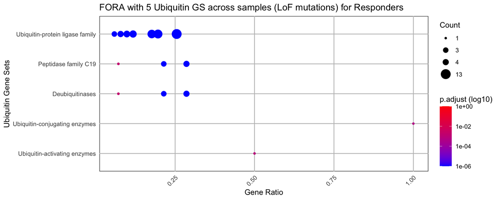

```r
## R
# Define output path
mm909_ubiquitin_lof_plot_path_r <- file.path(figures_ubfora_path,
                              "ub_unique_bubble_plot_R.png")

mm909_ubiquitin_lof_plot_r <- bubble_plot_pval(response_df, fora_results_ubiquitin_lof_df_r, mm909_ubiquitin_lof_plot_path_r, "FORA with 5 Ubiquitin GS across samples (LoF mutations) for Responders", "Ubiquitin Gene Sets")

print(mm909_ubiquitin_lof_plot_r)
```

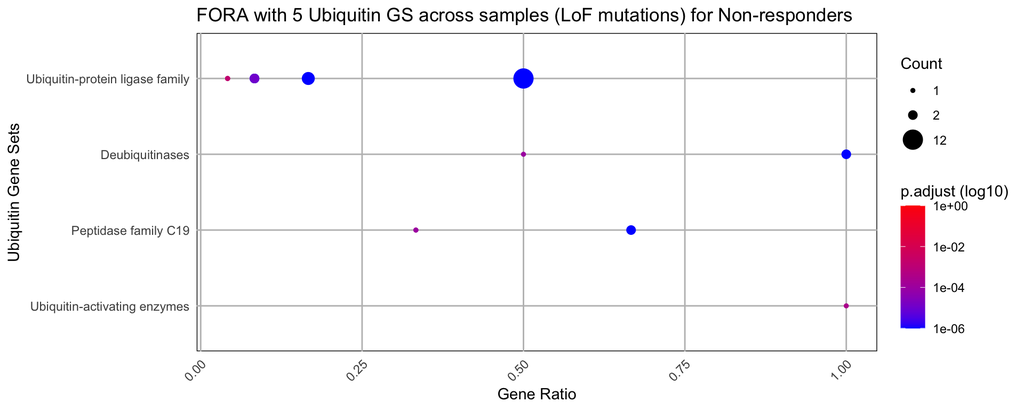

```r
## NR
# Define output path
mm909_ubiquitin_lof_plot_path_nr <- file.path(figures_ubfora_path,
                              "ub_unique_bubble_plot_NR.png")

mm909_ubiquitin_lof_plot_nr <- bubble_plot_pval(response_df, fora_results_ubiquitin_lof_df_nr, mm909_ubiquitin_lof_plot_path_nr, "FORA with 5 Ubiquitin GS across samples (LoF mutations) for Non-responders", "Ubiquitin Gene Sets")

print(mm909_ubiquitin_lof_plot_nr)
```

I don’t see a clear pattern with the bubble plots. It seems that sample MM909_03 (NR) is an “outlier” compared to the other NR samples, since it has a lot of mutations in Ub genes.

### 6.4.2 Heat map

This does not have the filter p.adjust < 0.05.

```r
plot_path_r <- file.path(figures_ubfora_path, "ub_unique_heat_map_R.pdf")
combinedGS_lof_plot_r <- complex_heatmap_genesets(response_df, fora_results_ubiquitin_lof_df_r, plot_path_r,
                                    "Heat Map gene counts per Gene Set stratified by patient (Responders)", 16, 6)

# Print
print(combinedGS_lof_plot_r)
```

[output not shown]

```r
plot_path_nr <- file.path(figures_ubfora_path, "ub_unique_heat_map_NR.pdf")
combinedGS_lof_plot_nr <- complex_heatmap_genesets(response_df, fora_results_ubiquitin_lof_df_nr, plot_path_nr,
                                    "Heat Map gene counts per Gene Set stratified by patient (Non-responders)", 16, 6)

# Print
print(combinedGS_lof_plot_nr)
```

[output not shown]

## 6.5 LoF mutations in unique Ubiquitin genes in R and NR -> annotation with Ub_db

```r
ub_db_csv_path <- file.path(results_ubgenesets_path, "ub_db.csv")
final_ub_db_df <- read.csv(ub_db_csv_path, header = TRUE)[ , -1]

# Filter for genes present in R & NR
final_ub_db_df <- final_ub_db_df %>%
  dplyr::filter(ensembl_id %in% glob_unique_ensembl_ids)

# Left join
joined_ub_info <- final_ub_db_df %>%
  dplyr::rename(category_db = category) %>%
  dplyr::left_join(annot_lof_df_ubiquitin, by="ensembl_id") %>%
  dplyr::distinct()

# Save to file
patients_ub_lof_mut_path <- file.path(results_ubfora_path,
                      "lof_patients_ub_mutations.csv")
write.csv(joined_ub_info, file = patients_ub_lof_mut_path, row.names = TRUE)

# Filter genes
r_final_ub_db_df <- joined_ub_info %>%
  dplyr::filter(corrected_hugo_symbol %in% unique_responder_genes)
nr_final_ub_db_df <- joined_ub_info %>%
  dplyr::filter(corrected_hugo_symbol %in% unique_non_responder_genes)

# FORA
# Define paths
fora_results_all_csv_path_r2 <- file.path(results_ubfora_path, "fora_results_ubiquitin_all_r2.csv")
fora_results_nonsyn_csv_path_r2 <- file.path(results_ubfora_path, "fora_results_ubiquitin_nonsyn_r2.csv")
fora_results_lof_csv_path_r2 <- file.path(results_ubfora_path, "fora_results_ubiquitin_lof_r2.csv")
fora_results_all_csv_path_nr2 <- file.path(results_ubfora_path, "fora_results_ubiquitin_all_nr2.csv")
fora_results_nonsyn_csv_path_nr2 <- file.path(results_ubfora_path, "fora_results_ubiquitin_nonsyn_nr2.csv")
fora_results_lof_csv_path_nr2 <- file.path(results_ubfora_path, "fora_results_ubiquitin_lof_nr2.csv")

# Adapt structure to gene_sets_list
gene_sets_df_r2 <- r_final_ub_db_df %>%
  dplyr::group_by(go_parent_term) %>%
  dplyr::summarise(ensembl_ids = list(unique(ensembl_id)), .groups = 'drop')
gene_sets_df_nr2 <- nr_final_ub_db_df %>%
  dplyr::group_by(go_parent_term) %>%
  dplyr::summarise(ensembl_ids = list(unique(ensembl_id)), .groups = 'drop')

# Convert the dataframe to a named list
gene_sets_list_r2 <- setNames(gene_sets_df_r2$ensembl_ids, gene_sets_df_r2$go_parent_term)
gene_sets_list_nr2 <- setNames(gene_sets_df_nr2$ensembl_ids, gene_sets_df_nr2$go_parent_term)

# Perform FORA analysis for Ubiquitin Gene Sets
# perform_fora_analysis(sample_id_list, list_of_all_ub_mutations, list_of_nonsyn_ub_mutations, list_of_lof_ub_mutations, fora_results_all_csv_path_r2, fora_results_nonsyn_csv_path_r2, fora_results_lof_csv_path_r2, gene_sets_list=gene_sets_list_r2)
# perform_fora_analysis(sample_id_list, list_of_all_ub_mutations, list_of_nonsyn_ub_mutations, list_of_lof_ub_mutations, fora_results_all_csv_path_nr2, fora_results_nonsyn_csv_path_nr2, fora_results_lof_csv_path_nr2, gene_sets_list=gene_sets_list_nr2)

# Load fora results (only LoF)
fora_results_ubiquitin_lof_df_r2 <- read.csv(fora_results_lof_csv_path_r2, header = TRUE)[ , -1]
fora_results_ubiquitin_lof_df_nr2 <- read.csv(fora_results_lof_csv_path_nr2, header = TRUE)[ , -1]
```

### 6.5.1 Bubble plot

This does not have the filter p.adjust < 0.05.

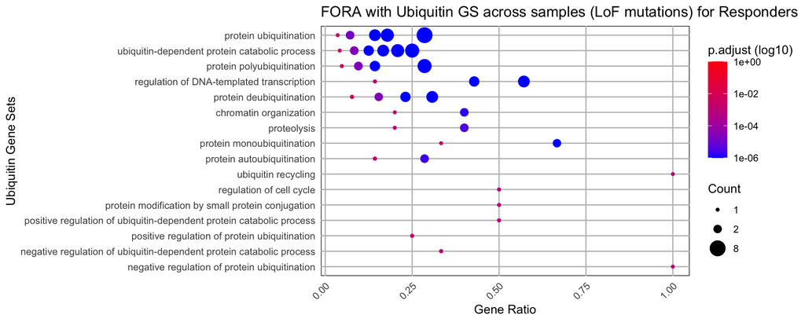

```r
## R
# Define output path
mm909_ubiquitin_lof_plot_path_r2 <- file.path(figures_ubfora_path,
                              "ub_unique_bubble_plot_R2.png")

mm909_ubiquitin_lof_plot_r2 <- bubble_plot_pval(response_df, fora_results_ubiquitin_lof_df_r2, mm909_ubiquitin_lof_plot_path_r2, "FORA with Ubiquitin GS across samples (LoF mutations) for Responders", "Ubiquitin Gene Sets")

print(mm909_ubiquitin_lof_plot_r2)
```

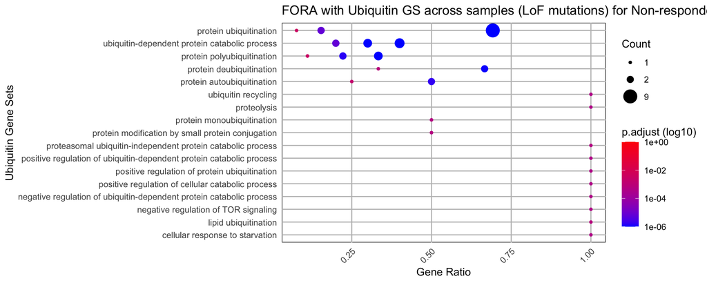

```r
## NR
# Define output path
mm909_ubiquitin_lof_plot_path_nr2 <- file.path(figures_ubfora_path,
                              "ub_unique_bubble_plot_NR2.png")

mm909_ubiquitin_lof_plot_nr2 <- bubble_plot_pval(response_df, fora_results_ubiquitin_lof_df_nr2, mm909_ubiquitin_lof_plot_path_nr2, "FORA with Ubiquitin GS across samples (LoF mutations) for Non-responders", "Ubiquitin Gene Sets")

print(mm909_ubiquitin_lof_plot_nr2)
```

### 6.5.2 Heat map

This does not have the filter p.adjust < 0.05.

```r
plot_path_r2 <- file.path(figures_ubfora_path, "ub_unique_heat_map_R2.pdf")
combinedGS_lof_plot_r2 <- complex_heatmap_genesets(response_df, fora_results_ubiquitin_lof_df_r2, plot_path_r2,
                                    "Heat Map gene counts per Gene Set stratified by patient (Responders)", 16, 6)

# Print
print(combinedGS_lof_plot_r2)
```

[output not shown]

```r
plot_path_nr2 <- file.path(figures_ubfora_path, "ub_unique_heat_map_NR2.pdf")
combinedGS_lof_plot_nr2 <- complex_heatmap_genesets(response_df, fora_results_ubiquitin_lof_df_nr2, plot_path_nr2,
                                    "Heat Map gene counts per Gene Set stratified by patient (Non-responders)", 16, 6)

# Print
print(combinedGS_lof_plot_nr2)
```

[output not shown]

## 6.6 Clustering by GO parent BP (C5 - BP)

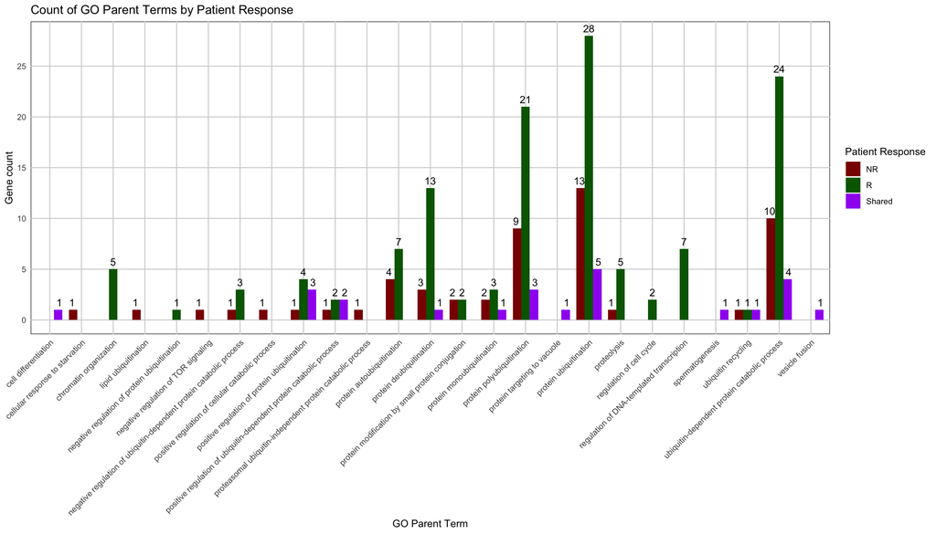

```r
# Filter genes
r_final_ub_db_df <- joined_ub_info %>%
  dplyr::filter(corrected_hugo_symbol %in% unique_responder_genes) %>%
  dplyr::select(ensembl_id, corrected_hugo_symbol, go_parent_term) %>%
  dplyr::distinct()
r_final_ub_db_df$source <- "R"
nr_final_ub_db_df <- joined_ub_info %>%
  dplyr::filter(corrected_hugo_symbol %in% unique_non_responder_genes) %>%
  dplyr::select(ensembl_id, corrected_hugo_symbol, go_parent_term) %>%
  dplyr::distinct()
nr_final_ub_db_df$source <- "NR"
shared_final_ub_db_df <- joined_ub_info %>%
  dplyr::filter(corrected_hugo_symbol %in% shared_genes) %>%
  dplyr::select(ensembl_id, corrected_hugo_symbol, go_parent_term) %>%
  dplyr::distinct()
shared_final_ub_db_df$source <- "Shared"

# Combine all data.frames into one
combined_df <- rbind(r_final_ub_db_df, nr_final_ub_db_df, shared_final_ub_db_df)

# Save to file
unique_shared_genes_path <- file.path(results_ubfora_path,
                      "unique_and_shared_genes_RvsNR.csv")
write.csv(combined_df, file = unique_shared_genes_path, row.names = TRUE)

# Calculate the counts
grouped_counts <- combined_df %>%
  dplyr::select(ensembl_id, go_parent_term, source) %>%
  group_by(go_parent_term, source) %>%
  summarise(count = n(), .groups = 'drop') %>%
  complete(go_parent_term, source, fill = list(count = 0)) %>%
  arrange(go_parent_term, source)

# Calculate the maximum count to set the y-axis limit dynamically
max_count <- max(grouped_counts$count, na.rm = TRUE)
buffer <- max_count * 0.1 # Add 10% buffer to the maximum count for the labels

# Create the bar plot
plot <- ggplot(grouped_counts, aes(x = go_parent_term, y = count, fill = source)) +
  geom_bar(stat = "identity", position = position_dodge(), width = 0.8) +  # dodge position to place bars side by side
  geom_text(aes(label = ifelse(count == 0, "", count)), vjust = -0.5, position = position_dodge(0.9)) +  # Exclude "0" labels
  scale_fill_manual(values = c("R" = "darkgreen", "NR" = "darkred", "Shared" = "purple")) +
  labs(title = "Count of GO Parent Terms by Patient Response",
       x = "GO Parent Term",
       y = "Gene count",
       fill = "Patient Response") +
  ylim(0, max_count + buffer) + # Adjust the y-axis to include the buffer
  theme_minimal() +
  theme(
      panel.grid.major = element_line(color = "lightgrey", linewidth = 0.5),
      panel.grid.minor = element_blank(),
      panel.background = element_rect(fill = "white", colour = "black"),
      plot.background = element_rect(fill = "white", colour = NA),
      axis.text.x = element_text(angle = 45, hjust = 1, vjust = 1)) +  # Rotate X-axis labels for better readability
  scale_y_continuous(breaks = seq(0, max_count, by = 5),  # Ticks every 5 units
                     minor_breaks = seq(0, max_count, by = 1))  # Minor ticks every 1 unit

# Print the plot
print(plot)
```